# Data Challenge competition - Football prediction - AWAY WIN PREDICTION

Attila Gulyás / Team Bella Vita

Note: - Data was provided by the organizer of the competition. It is found to be clean, no missing values, no duplicates. - There are 23 divisions and 10 seasons in the data.

| BASIC SETUP |
| --- |

```r
# empty memory
rm(list=ls())

# KOMMENT: install library if not exist -> megoldani majd

# Load libraries
library("tidyverse") # imap function for roc curve
library("data.table") # to use data in an efficient way
library("readxl") # to read xlsx data
library("caret") # to split data into train and holdput sets
library("dplyr") # to append commands easier
library("ROCR") # to evaluate model performance
library("h2o") # for autoML, java is kell hozzá
library("xgboost") # for extreme gradient boosting model
library("e1071") # for Naive Bayes
library("ranger") # for RF model
library("kernlab") # for SVM
library("mltools") # to calculate AUC manually
library("glmnet") # for GLMNET model
# library(ggplot2)
# library(ggthemes)
# library(grid)
# library(lattice)
# library(glmnet)
# library("skimr")
# library(gridExtra)

# Set the working directory
dir <-  "/Users/attilagulyas/Documents/GitHub/DataChallenge2023/"

#location folders
data_in <- paste0(dir,"01_raw/")
# func <- paste0(dir, "work/") - nem használt
output <- paste0(dir, "04_output/")
```

| LOAD DATA |
| --- |

```r
data <- as.data.table(read_excel(paste0(data_in, "competition_table.xlsx")))


# BASIC STISTICS
message(paste0("Döntetlen aránya: ", round(sum(data$draw_flag) / nrow(data), digits = 2)))
```

```
Döntetlen aránya: 0.26
```

```r
message(paste0("Hazai győzelem aránya: ", round(sum(data$home_win_flag) / nrow(data), digits = 2)))
```

```
Hazai győzelem aránya: 0.44
```

```r
message(paste0("Vendég győzelem aránya: ", round(sum(data$away_win_flag) / nrow(data), digits = 2)))
```

```
Vendég győzelem aránya: 0.3
```

| LABEL ENGINEERING |
| --- |

```r
data <- data %>%
  mutate(home_win_flag = factor(ifelse(home_win_flag == 0, "no", "yes"), levels = c("no", "yes")))

data <- data %>%
  mutate(away_win_flag = factor(ifelse(away_win_flag == 0, "no", "yes"), levels = c("no", "yes")))

data <- data %>%
  mutate(draw_flag = factor(ifelse(draw_flag == 0, "no", "yes"), levels = c("no", "yes")))
```

| FEATURE ENGINEERING |
| --- |

```r
# data structure
# str(data)
data <- data %>% mutate(
        # hazai csapat támadás erőssége előző meccsen
        home_goal_per_shot_roll1 = home_team_goal_roll1_sum / home_team_shot_roll1_sum,
        home_goal_per_shotontarget_roll1 = home_team_goal_roll1_sum / home_team_shot_on_target_roll1_sum,
        home_shotontarget_per_shots_roll1 = home_team_shot_on_target_roll1_sum / home_team_shot_roll1_sum,
        # hazai csapat támadás erőssége előző 4 meccsen
        home_goal_per_shot_roll4 = home_team_goal_roll4_sum / home_team_shot_roll4_sum,
        home_goal_per_shotontarget_roll4 = home_team_goal_roll4_sum / home_team_shot_on_target_roll4_sum,
        home_shotontarget_per_shots_roll4 = home_team_shot_on_target_roll4_sum / home_team_shot_roll4_sum,
        # vendég csapat támadás erőssége előző meccsen
        away_goal_per_shot_roll1 = away_team_goal_roll1_sum / away_team_shot_roll1_sum,
        away_goal_per_shotontarget_roll1 = away_team_goal_roll1_sum / away_team_shot_on_target_roll1_sum,
        away_shotontarget_per_shots_roll1 = away_team_shot_on_target_roll1_sum / away_team_shot_roll1_sum,
        # vendég csapat támadás erőssége előző 4 meccsen
        away_goal_per_shot_roll4 = away_team_goal_roll4_sum / away_team_shot_roll4_sum,
        away_goal_per_shotontarget_roll4 = away_team_goal_roll4_sum / away_team_shot_on_target_roll4_sum,
        away_shotontarget_per_shots_roll4 = away_team_shot_on_target_roll4_sum / away_team_shot_roll4_sum,

        # hazai csapat védekezés erőssége előző meccsen
        home_opponents_goal_per_shot_roll1 =
          home_team_opponents_goal_roll1_sum / home_team_opponents_shot_roll1_sum,
        home_opponents_goal_per_shotontarget_roll1 =
          home_team_opponents_goal_roll1_sum /     home_team_opponents_shot_on_target_roll1_sum,
        home_opponents_shotontarget_per_shots_roll1 =
          home_team_opponents_shot_on_target_roll1_sum / home_team_opponents_shot_roll1_sum,

        # hazai csapat védekezés erőssége előző 4 meccsen
        home_opponents_goal_per_shot_roll4 =
          home_team_opponents_goal_roll4_sum / home_team_opponents_shot_roll4_sum,
        home_opponents_goal_per_shotontarget_roll4 =
          home_team_opponents_goal_roll4_sum /     home_team_opponents_shot_on_target_roll4_sum,
        home_opponents_shotontarget_per_shots_roll4 =
          home_team_opponents_shot_on_target_roll4_sum / home_team_opponents_shot_roll4_sum,

        # vendég csapat védekezés erőssége előző meccsen
        away_opponents_goal_per_shot_roll1 =
          away_team_opponents_goal_roll1_sum / away_team_opponents_shot_roll1_sum,
        away_opponents_goal_per_shotontarget_roll1 =
          away_team_opponents_goal_roll1_sum /     away_team_opponents_shot_on_target_roll1_sum,
        away_opponents_shotontarget_per_shots_roll1 =
          away_team_opponents_shot_on_target_roll1_sum / away_team_opponents_shot_roll1_sum,

        # vendég csapat védekezés erőssége előző 4 meccsen
        away_opponents_goal_per_shot_roll4 =
          away_team_opponents_goal_roll4_sum / away_team_opponents_shot_roll4_sum,
        away_opponents_goal_per_shotontarget_roll4 =
          away_team_opponents_goal_roll4_sum /     away_team_opponents_shot_on_target_roll4_sum,
        away_opponents_shotontarget_per_shots_roll4 =
          away_team_opponents_shot_on_target_roll4_sum / away_team_opponents_shot_roll4_sum
)


# nullás osztás miatti hibás értékek javítása
data[,168:191] <- lapply(data[,168:191], function(x) {x[is.infinite(x)] <- 0; return(x)}) %>% as.data.table()
data[,168:191] <- lapply(data[,168:191], function(x) {x[is.na(x)] <- 0; return(x)}) %>% as.data.table()
```

[output not shown]

Create training set and holdout set samples

```r
set.seed(1990)

# smaller than usual training set so that models run faster - megj: 70% helyett 80%-ot használok
train_indices <- createDataPartition(data$away_win_flag, p = 0.8, list = FALSE)
data_train <- data[train_indices, ]

data_holdout <- data[-train_indices, ]

dim(data_train)
```

```
[1] 51334   191
```

```r
dim(data_holdout)
```

```
[1] 12832   191
```

Set evaluation rules Megj: 10-fold CV, repeated CV is megoldás lehet, kipróbálni

```r
train_control <- trainControl(
  method = "cv", #"repeatedcv",
  n = 10,
  classProbs = TRUE,
  summaryFunction = twoClassSummary  # necessary!
)

# MEGJ: repeated CV is egy megoldás

# Define the control parameters for the train function
# ctrl <- trainControl(method = "repeatedcv", number = 10, repeats = 3,
#                      classProbs = TRUE, summaryFunction = twoClassSummary)
```

Define variables

```r
# Basic numeric variables
basic_numeric_vars_set0 <- c(
  "odds_home_team_win",
  "odds_away_team_win"
)

basic_numeric_vars_set1 <- c(
  "odds_home_team_win",
  "odds_away_team_win",
  "odds_draw"
)

# glmnet (elastic net penalized) based selection
basic_numeric_vars_set2 <- c("odds_away_team_win",  # !
                             "odds_home_team_win",  # !

                             "home_team_expected_point_roll4_sum",  # !

                             "away_team_expected_point_roll4_sum",
                             "away_team_expected_point_roll3_sum",
                             "home_team_expected_point_mean",  # !
                              # "away_team_expected_point_roll4_sum",  # !
                              # "away_team_expected_point_roll3_sum",
                              "away_team_expected_point_mean",  # !
                              "home_team_expected_point_mean",
                              # "home_team_corner_roll4_sum", # ?  # !
                              # "home_team_corner_roll3_sum", # ?
                              # "home_team_corner_roll2_sum", # ?  # !
                              # "away_team_opponents_corner_roll4_sum", # ?  # !

                             "away_team_corner_roll4_sum", # human input
                              "away_team_corner_roll3_sum",
                              "away_team_corner_roll2_sum", # human input

                            "home_team_opponents_corner_roll2_sum", # ?
                            "away_team_shot_roll2_sum", # human input

                              # "home_team_shot_roll2_sum", # ?  # !
                              # "away_team_opponents_shot_roll1_sum",  # ?  # !
                              "away_team_opponents_shot_roll4_sum", # ?  # !
                              # "away_team_opponents_shot_roll3_sum", # ?  # !

                              # "away_team_opponents_shot_on_target_roll4_sum",  # !
                             "home_team_opponents_shot_on_target_roll2_sum",
                             "home_team_shot_on_target_roll3_sum"
                             # "odds_home_team_defeat_roll4_mean",
                             # "odds_home_team_defeat_roll3_mean",
                             # "odds_away_team_win_roll1_mean",
                             # "odds_home_team_defeat_roll2_mean",
                             # "odds_away_team_win_roll4_mean",
                             # "home_team_opponents_yellow_card_roll3_sum"
                             )


# xgb based selection
basic_numeric_vars_set3 <- c("odds_away_team_win", # !
                             "odds_home_team_win", # !
                             "odds_draw", # !

                             "odds_home_team_defeat_roll4_mean", # !
                             "odds_home_team_defeat_roll3_mean", # human input
                             "odds_home_team_defeat_roll2_mean",

                             "odds_away_team_defeat_roll4_mean",
                             "odds_away_team_defeat_roll3_mean", # # ! human input
                             "odds_away_team_defeat_roll2_mean", # human input

                             "odds_away_team_win_roll4_mean", # !
                             "odds_away_team_win_roll3_mean",

                             "odds_home_team_win_roll4_mean", # human input
                             "odds_home_team_win_roll3_mean",

                              "odds_home_team_draw_roll4_mean",
                             "odds_home_team_draw_roll3_mean", # human input
                             "odds_away_team_draw_roll4_mean", # human input
                             "odds_away_team_draw_roll3_mean",

                              "away_team_expected_point_mean", # !
                             "home_team_expected_point_mean", # human input
                              "home_team_corner_roll3_sum", # ?
                              "away_team_corner_roll2_sum", # ?
                              "away_team_opponents_corner_roll4_sum", # ?

                             "home_team_shot_roll2_sum", # ?
                             "home_team_shot_roll4_sum", # ?
                             "home_shotontarget_per_shots_roll4",
                             "away_team_opponents_shot_roll4_sum", # ?
                             "away_team_opponents_shot_on_target_roll3_sum"

                             )


# random forest based selection
basic_numeric_vars_set4 <- c("odds_away_team_win",
                             "odds_home_team_win",
                             "odds_draw",

                             "odds_home_team_defeat_roll4_mean",
                             "odds_home_team_defeat_roll3_mean",
                             "odds_home_team_defeat_roll2_mean",
                             "odds_home_team_defeat_roll1_mean", # human input

                             "odds_away_team_defeat_roll4_mean",
                             "odds_away_team_defeat_roll3_mean",
                             "odds_away_team_defeat_roll2_mean",
                             "odds_away_team_defeat_roll1_mean", # human input

                             "odds_home_team_win_roll4_mean",
                             "odds_home_team_win_roll3_mean",
                             "odds_home_team_win_roll2_mean",
                             "odds_home_team_win_roll1_mean",

                             "odds_away_team_win_roll4_mean",
                             "odds_away_team_win_roll3_mean",
                             "odds_away_team_win_roll2_mean",
                             "odds_away_team_win_roll1_mean",

                             # "odds_away_team_draw_roll4_mean",

                             "home_team_expected_point_roll4_sum",
                             "away_team_expected_point_roll4_sum",  # human input
                             "away_team_expected_point_mean",
                             "home_team_expected_point_mean"
                             )

# best variables in logistic regression
basic_numeric_vars_set5 <- c("odds_home_team_win",
                             "odds_away_team_win",
                             "odds_draw",
                             "away_team_expected_point_mean",
                             "away_team_point_mean",
                             # "home_team_expected_point_roll4_sum",
                             # "home_team_point_roll4_sum",
                             "odds_home_team_defeat_roll3_mean"
                             )




# Log variables
# Higher order variables
# Factorized variables
# Dummy variables
```

Define predictor sets

```r
# basic two odds
predictors_0 <- c(basic_numeric_vars_set0)

# basic three odds
predictors_1 <- c(basic_numeric_vars_set1)

# all variables
predictors_2 <- colnames(data[,-c("home_win_flag", "draw_flag", "away_win_flag", "match_id")])

# glmnet (elastic net penalized) based selection
predictors_3 <- c(basic_numeric_vars_set2)

# xgb based selection
predictors_4 <- c(basic_numeric_vars_set3)

# random forest based selection
predictors_5 <- c(basic_numeric_vars_set4)

# best variables in logistic regression
predictors_6 <- c(basic_numeric_vars_set5)
```

| MODELLEK: |
| --- |

## AutoML model: baseline model

```r
h2o.init()
data_train_h2o <- as.h2o(data_train[,-c("home_win_flag", "draw_flag")])

# Define the target variable
target <- "away_win_flag"

# Split data into training and validation sets
splits <- h2o.splitFrame(data_train_h2o, ratios = 0.8, seed = 1234)
train <- splits[[1]]
valid <- splits[[2]]

set.seed(857)
# Run AutoML for 20 base models
aml = h2o.automl(x = predictors_2, y = target,
                 training_frame = train,
                 validation_frame = valid,
                 max_models = 20,
                 seed = 1,
                 max_runtime_secs = 20
)

# AutoML Leaderboard
lb = aml@leaderboard
lb

# close h2o connection
h2o.shutdown(prompt = F)
```

## Logistic regression

```r
#  train the model
set.seed(857)

# basic 3 odds variable
glm_model <- train(away_win_flag ~ .,
                   data = data_train[ ,colnames(data_train) %in% c("away_win_flag", predictors_1), with=FALSE],
                   method = "glm",
                   trControl = train_control)
```

```r
# model summary
summary(glm_model)
```

```r
# AUC on validation set
auc_cv <- glm_model[["results"]][["ROC"]]
message(paste0("AUC from CV: ", round(auc_cv, digits = 4)))
```

```
AUC from CV: 0.6894
```

```r
 # 0.689

sensitivity_cv <- glm_model[["results"]][["Sens"]]
message(paste0("Sensitivity from CV: ", round(sensitivity_cv, digits = 4)))
```

```
Sensitivity from CV: 0.9646
```

```r
# 0.9654
```

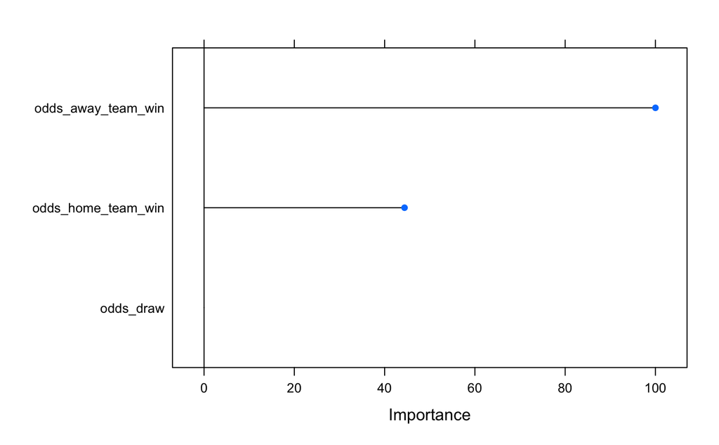

```r
# variable importance
varimp <- varImp(glm_model)
plot(varImp(glm_model))
```

```r
varimp
```

```
glm variable importance
```

|  | Overall |
| --- | --- |
| odds_away_team_win | 100.00000 |
| odds_home_team_win | 44.41064 |
| odds_draw | 0.00000 |

## Bayes Logistic regression

```r
#  train the model
set.seed(857)

# basic 3 odds variable
bayesglm_model <- train(away_win_flag ~ .,
                   data = data_train[ ,colnames(data_train) %in% c("away_win_flag", predictors_1), with=FALSE],
                   method = "bayesglm",
                   trControl = train_control)
```

```r
# model summary
summary(bayesglm_model)
```

```r
# AUC on validation set
auc_cv <- bayesglm_model[["results"]][["ROC"]]
message(paste0("AUC from CV: ", round(auc_cv, digits = 4)))
```

```
AUC from CV: 0.6894
```

```r
 # 0.689

sensitivity_cv <- bayesglm_model[["results"]][["Sens"]]
message(paste0("Sensitivity from CV: ", round(sensitivity_cv, digits = 4)))
```

```
Sensitivity from CV: 0.9646
```

```r
# 0.9654
```

```r
# variable importance
varimp <- varImp(bayesglm_model)
```

## GLMNET model (Reguralized logistic regression)

```r
#  train the model
set.seed(857)

tune_grid_glmnet <- expand.grid(
               alpha = 0, #seq(from = 0, to = 1, by = 0.1), #ridge: 0, lasso: 1, elastic net: [0,1]
               lambda = 0.2 #seq(0.0001, 1, length = 100)
)

# xbg feature selection is the best, but glmnet selection is very good too
glmnet_model <- train(away_win_flag ~ .,
                   data = data_train[ ,colnames(data_train) %in% c("away_win_flag", predictors_1), with=FALSE],
                   method = "glmnet",
                   trControl = train_control,
                   tuneGrid = tune_grid_glmnet)
```

```r
# find the best parameters

best_lambda<- glmnet_model$bestTune$lambda
message(paste0(" best lambda: ", round(best_lambda, digits = 4)))
```

```
 best lambda: 0.2
```

```r
best_alpha<- glmnet_model$bestTune$alpha
message(paste0(" best alpha: ", round(best_alpha, digits = 4)))
```

```
 best alpha: 0
```

```r
# AUC on validation set
auc_cv <- glmnet_model[["results"]][["ROC"]]
message(paste0("AUC from CV: ", round(auc_cv, digits = 4)))
```

```
AUC from CV: 0.6708
```

```r
# 0.6874

sensitivity_cv <- glmnet_model[["results"]][["Sens"]]
message(paste0("Sensitivity from CV: ", round(sensitivity_cv, digits = 4)))
```

```
Sensitivity from CV: 0.8951
```

```r
# 0.9913
```

```r
# model summary
# summary(glmnet_model)
```

[figure not shown]

```r
# variable importance
varimp <- varImp(glmnet_model)
plot(varImp(glmnet_model))
```

```r
varimp
```

[output not shown]

[output not shown]

[output cut: 10 more lines]

## Extreme Gradient Boosting

```r
#  train the model
set.seed(19900829)
tune_grid_xgb <- expand.grid(
  nrounds = 100, #(10, 100),  # this is n_estimators in python code
  max_depth = 3, #c(3,10),
  colsample_bytree = 0.8, # seq(0.5, 0.9, length.out = 5),
  ## The values below are default values in the sklearn-api.
  eta = 0.01, #c(0.01, 0.3),
  gamma= 10, #c(0,10),
  min_child_weight = 10, #c(1, 10),
  subsample = 1 #c(0.5, 1)
)

# xgb feature selection is good, but all feature is the best
xgb_model <- train(
  away_win_flag ~ .,
  data = data_train[ ,colnames(data_train) %in% c("away_win_flag", predictors_4), with=FALSE],
  tuneLength = 1,
  method = 'xgbTree',
  na.action = na.omit,
  # importance = 'permutation',
  # mtry: cannot be more than the number of predictors
  tuneGrid = tune_grid_xgb,
  trControl = train_control)
```

```r
# find the best parameters
best_nrounds <- xgb_model$bestTune$nrounds
message(paste0(" best nrounds: ", round(best_nrounds, digits = 4)))

best_max_depth <- xgb_model$bestTune$max_depth
message(paste0(" best max_depth : ", round(best_max_depth, digits = 4)))

best_colsample_bytree <- xgb_model$bestTune$colsample_bytree
message(paste0(" best colsample_bytree : ", round(best_colsample_bytree, digits = 4)))

best_eta <- xgb_model$bestTune$eta
message(paste0(" best eta : ", round(best_eta, digits = 4)))

best_gamma<- xgb_model$bestTune$gamma
message(paste0(" best gamma : ", round(best_gamma, digits = 4)))

best_min_child_weight<- xgb_model$bestTune$min_child_weight
message(paste0(" best min_child_weight : ", round(best_min_child_weight, digits = 4)))

best_subsample<- xgb_model$bestTune$subsample
message(paste0(" best subsample : ", round(best_subsample, digits = 4)))
```

```r
# AUC on validation set
auc_cv <- xgb_model[["results"]][["ROC"]]
message(paste0("AUC from CV: ", round(auc_cv, digits = 4)))
# 0.6878

sensitivity_cv <- xgb_model[["results"]][["Sens"]]
message(paste0("Sensitivity from CV: ", round(sensitivity_cv, digits = 4)))
# 0.9443
```

```r
# model summary
# summary(xgb_model)
```

```r
# variable importance
varimp <- varImp(xgb_model)
plot(varImp(xgb_model))
varimp
```

A celebrated implementation of the gradient boosting idea. Both xgboost and gbm follows the principle of gradient boosting. There are however, the difference in modeling details. Specifically, xgboost used a more regularized model formalization to control over-fitting, which gives it better performance.

## “Simple” Gradient Boosting Machine

```r
#  train the model
set.seed(19900829)
tune_grid_gbm <- expand.grid(n.trees = 200, #c(100, 200), # 200
                        interaction.depth = 5, # c(5, 10), # 5
                        shrinkage = 0.01, #c(0.005, 0.01, 0.1), # 0.01
                        n.minobsinnode = 50) #c(5, 50)) # 50

# glmnet is the best feature selection
gbm_model <- train(away_win_flag ~ .,
                   data = data_train[ ,colnames(data_train) %in% c("away_win_flag", predictors_3
                                                                   ), with=FALSE],
                   method = "gbm",
                   trControl = train_control,
                   tuneGrid = tune_grid_gbm,
                   bag.fraction = 0.8,
                   verbose = FALSE # gbm by default prints too much output
)
```

```r
# find the best parameters
best_n.trees <- gbm_model$bestTune$n.trees
message(paste0(" best n.trees: ", round(best_n.trees, digits = 4)))
```

```
 best n.trees: 200
```

```r
best_interaction.depth <- gbm_model$bestTune$interaction.depth
message(paste0(" best interaction.depth: ", round(best_interaction.depth, digits = 4)))
```

[output not shown]

```r
best_shrinkage <- gbm_model$bestTune$shrinkage
message(paste0(" best shrinkage: ", round(best_shrinkage, digits = 4)))
```

```
 best shrinkage: 0.01
```

```r
best_n.minobsinnode <- gbm_model$bestTune$n.minobsinnode
message(paste0(" best n.minobsinnode: ", round(best_n.minobsinnode, digits = 4)))
```

```
 best n.minobsinnode: 50
```

```r
# AUC on validation set
auc_cv <- gbm_model[["results"]][["ROC"]]
message(paste0("AUC from CV: ", round(auc_cv, digits = 4)))
```

```
AUC from CV: 0.689
```

```r
# 0.6891

sensitivity_cv <- gbm_model[["results"]][["Sens"]]
message(paste0("Sensitivity from CV: ", round(sensitivity_cv, digits = 4)))
```

```
Sensitivity from CV: 0.9729
```

```r
# 0.9727
```

```r
# model summary
# summary(gbm_model)
```

```r
# varimp <- varImp(gbm_model)
# plot(varImp(gbm_model))
```

## Naive Bayes

```r
#  train the model
set.seed(19900829)

# basic 3 predictors are the the best (nem éri meg többet bevonni)
nb_model <- train(away_win_flag ~ .,
                  data = data_train[ ,colnames(data_train) %in% c("away_win_flag", predictors_0), with=FALSE],
                  method = "naive_bayes",
                  trControl = train_control, verbose = FALSE)
```

[output not shown]

```r
# model summary
summary(nb_model)
```

```r
# AUC on validation set
auc_cv <- nb_model[["results"]][["ROC"]]
message(paste0("AUC from CV: ", round(auc_cv, digits = 4)))
```

[output not shown]

```r
# 0.688

sensitivity_cv <- nb_model[["results"]][["Sens"]]
message(paste0("Sensitivity from CV: ", round(sensitivity_cv, digits = 4)))
```

[output not shown]

```r
# 0.86
```

```r
varimp <- varImp(nb_model)
plot(varImp(nb_model))
```

## Random Forest

```r
#  train the model
set.seed(19900829)
tune_grid_rf <- expand.grid(
  .mtry = 20, # c(3,10,20), # 2
  .splitrule = "gini", # variance
  .min.node.size = 1000 #c(5, 500, 1000) # 1-2 % of training set 1000
)

# random forest is the best feature selection
rf_model <- train(
  away_win_flag ~ .,
  data = data_train[ ,colnames(data_train) %in% c("away_win_flag", predictors_5), with=FALSE],
  tuneLength = 1,
  method = 'ranger',
  na.action = na.omit,
  importance = 'permutation',
  # mtry: cannot be more than the number of predictors
  tuneGrid = tune_grid_rf,
  trControl = train_control)
```

```r
# find the best parameters
best_mtry <- rf_model$bestTune$mtry
message(paste0(" best mtry: ", round(best_mtry, digits = 4)))
```

```
 best mtry: 20
```

```r
best_min.node.size<- rf_model$bestTune$min.node.size
message(paste0(" best min.node.size: ", round(best_min.node.size, digits = 4)))
```

```
 best min.node.size: 1000
```

```r
# AUC on validation set
auc_cv <- rf_model[["results"]][["ROC"]]
message(paste0("AUC from CV: ", round(auc_cv, digits = 4)))
```

```
AUC from CV: 0.6855
```

```r
# 0.6877

sensitivity_cv <- rf_model[["results"]][["Sens"]]
message(paste0("Sensitivity from CV: ", round(sensitivity_cv, digits = 4)))
```

```
Sensitivity from CV: 0.9444
```

```r
# 0.9443
```

```r
# model summary
summary(rf_model)
```

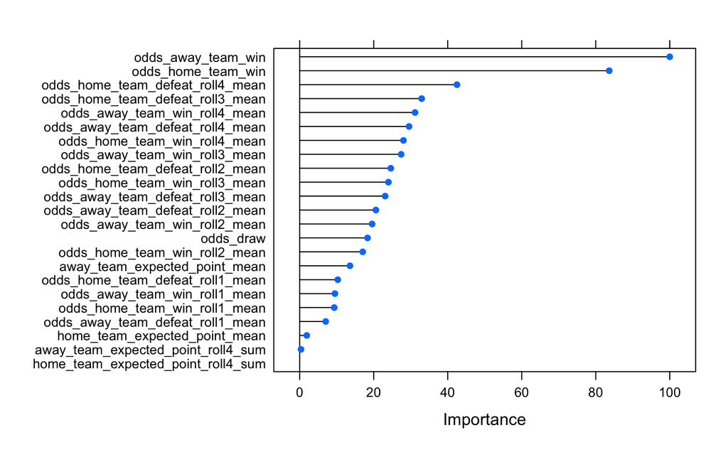

```r
varimp <- varImp(rf_model)
plot(varImp(rf_model))
```

```r
varimp
```

```
ranger variable importance

  only 20 most important variables shown (out of 23)
```

|  | Overall |
| --- | --- |
| odds_away_team_win | 100.000000 |
| odds_home_team_win | 83.647636 |
| odds_home_team_defeat_roll4_mean | 42.497610 |
| odds_home_team_defeat_roll3_mean | 32.959608 |
| odds_away_team_win_roll4_mean | 31.172837 |
| odds_away_team_defeat_roll4_mean | 29.544930 |
| odds_home_team_win_roll4_mean | 28.041763 |
| odds_away_team_win_roll3_mean | 27.420717 |
| odds_home_team_defeat_roll2_mean | 24.619576 |
| odds_home_team_win_roll3_mean | 23.982283 |

[output cut: 10 more lines]

## SVM

```r
#  train the model
set.seed(19900829)
tune_grid_svm <- expand.grid(
  .C = 0.01 #c(0.001, 0.01, 0.1, 1)
)

# xgb feature selection is used
svm_model <- train(
  away_win_flag ~ .,
  data = data_train[ ,colnames(data_train) %in% c("away_win_flag", predictors_0), with=FALSE],
  tuneLength = 1,
  method = 'svmLinear',
  na.action = na.omit,
  importance = 'permutation',
  # mtry: cannot be more than the number of predictors
  tuneGrid = tune_grid_svm,
  trControl = train_control)
```

```r
# find the best parameters
best_C<- svm_model$bestTune$C
message(paste0(" best C: ", round(best_C, digits = 4)))
```

```r
# model summary
summary(svm_model)
```

```r
# AUC on validation set
auc_cv <- svm_model[["results"]][["ROC"]]
message(paste0("AUC from CV: ", round(auc_cv, digits = 4)))
# 0.6762

sensitivity_cv <- svm_model[["results"]][["Sens"]]
message(paste0("Sensitivity from CV: ", round(sensitivity_cv, digits = 4)))
# 0.97
```

```r
varimp <- varImp(svm_model)
plot(varImp(svm_model))
```

## K-Nearest Neighbours

```r
#  train the model
set.seed(19900829)
tune_grid_knn <- expand.grid(
  .k= 10 #c(5, 10)
)


# basic 3 predictors are the the best (nem éri meg többet bevonni), nem erős modell
knn_model <- train(
  away_win_flag ~ .,
  data = data_train[ ,colnames(data_train) %in% c("away_win_flag", predictors_0), with=FALSE],
  tuneLength = 1,
  method = 'knn',
  na.action = na.omit,
  # importance = 'permutation',
  # mtry: cannot be more than the number of predictors
  tuneGrid = tune_grid_knn,
  trControl = train_control)
```

```r
# find the best parameters
best_k<- knn_model$bestTune$k
message(paste0(" best k: ", round(best_k, digits = 4)))
```

```r
# find the best parameters
# library(class)
# x <- data_train[,c(predictors_1), with = FALSE]
# y <- data_train[,"away_win_flag"]
#
#
# # Tune k-NN model using cross-validation
# knn_tune <- tune.knn(x, y, k = 1:2, tunecontrol = tune.control(sampling = "cross"))
#
# print(knn_tune)
```

```r
# model summary
summary(knn_model)
```

```r
# AUC on validation set
auc_cv <- knn_model[["results"]][["ROC"]]
message(paste0("AUC from CV: ", round(auc_cv, digits = 4)))
```

```
AUC from CV: 0.6655
```

```r
# 0.6637

sensitivity_cv <- knn_model[["results"]][["Sens"]]
message(paste0("Sensitivity from CV: ", round(sensitivity_cv, digits = 4)))
```

```
Sensitivity from CV: 0.924
```

```r
# 0.9277
```

```r
varimp <- varImp(knn_model)
plot(varImp(knn_model))
```

## ENSEMBLED MODEL

```r
h2o.init()
data_train_h2o <- as.h2o(data_train[,-c("home_win_flag", "draw_flag", "match_id")])

# Identify predictors and response
y <- "away_win_flag"
x <- predictors_2

# Train & Cross-validate a GBM
my_gbm <- h2o.gbm(x = x,
                  y = y,
                  training_frame = data_train_h2o,
                  nfolds = 10,
                  keep_cross_validation_predictions = TRUE,
                  seed = 5)

# Train & Cross-validate a RF
my_rf <- h2o.randomForest(x = x,
                          y = y,
                          training_frame = data_train_h2o,
                          nfolds = 10,
                          keep_cross_validation_predictions = TRUE,
                          seed = 5)
# Train & Cross-validate a LR
my_lr <- h2o.glm(x = x,
                 y = y,
                 training_frame = data_train_h2o,
                 family = c("binomial"),
                 nfolds = 10,
                 keep_cross_validation_predictions = TRUE,
                 seed = 5)
# Train a stacked random forest ensemble using the GBM, RF and LR above
ensemble <- h2o.stackedEnsemble(x = x,
                                y = y,
                                metalearner_algorithm="drf",
                                training_frame = data_train_h2o,
                                base_models = list(my_gbm, my_rf, my_lr))
```

```r
# model summary
summary(ensemble)
```

| EVALUATION: Compare random forests models based on VALIDATION sets |
| --- |

```r
results <- resamples(
  list(
    #model_1 = aml,
    GLM = glm_model,
    BAYESGLM = bayesglm_model,
    GLMNET = glmnet_model,
    XGB = xgb_model,
    GMB = gbm_model,
    NB = nb_model,
    RF = rf_model,
    SVM = svm_model,
    KNN = knn_model
    #model_9 = ensemble
  )
)
summary(results)
```

| EVALUATION: Compare random forests models based on TEST set |
| --- |

Logistic regression

```r
# AUC on holdout set
predicted_glm_holdout <- predict(glm_model,
                                 newdata = data_holdout,
                                 type = "prob")[["yes"]]


prediction_holdout_glm <- prediction(predicted_glm_holdout, data_holdout$away_win_flag)
auc_holdout_glm <- performance(prediction_holdout_glm, measure = "auc")@y.values[[1]]
message(paste0("AUC on holdout set for GLM: ", round(auc_holdout_glm, digits = 4)))
```

```
AUC on holdout set for GLM: 0.6826
```

Bayesian Logistic regression

```r
# AUC on holdout set
predicted_bayesglm_holdout <- predict(bayesglm_model,
                                 newdata = data_holdout,
                                 type = "prob")[["yes"]]


prediction_holdout_bayesglm <- prediction(predicted_bayesglm_holdout, data_holdout$away_win_flag)
auc_holdout_bayesglm <- performance(prediction_holdout_bayesglm, measure = "auc")@y.values[[1]]
message(paste0("AUC on holdout set for Bayes GLM: ", round(auc_holdout_bayesglm, digits = 4)))
```

```
AUC on holdout set for Bayes GLM: 0.6825
```

GLMNET

```r
# AUC on holdout set
predicted_glmnet_holdout <- predict(glmnet_model,
                                 newdata = data_holdout,
                                 type = "prob")[["yes"]]


prediction_holdout_glmnet <- prediction(predicted_glmnet_holdout, data_holdout$away_win_flag)
auc_holdout_glmnet <- performance(prediction_holdout_glmnet, measure = "auc")@y.values[[1]]
message(paste0("AUC on holdout set for GLM Net: ", round(auc_holdout_glmnet, digits = 4)))
```

```
AUC on holdout set for GLM Net: 0.6807
```

Random forest

```r
# AUC on holdout set
predicted_rf_holdout <- predict(rf_model,
                         newdata = data_holdout,
                         type = "prob")[["yes"]]


prediction_holdout_rf <- prediction(predicted_rf_holdout, data_holdout$away_win_flag)
auc_holdout_rf <- performance(prediction_holdout_rf, measure = "auc")@y.values[[1]]
message(paste0("AUC on holdout set for RF: ", round(auc_holdout_rf, digits = 4)))
```

```
AUC on holdout set for RF: 0.6792
```

XGBoosting

```r
# AUC on holdout set
predicted_xgb_holdout <- predict(xgb_model,
                         newdata = data_holdout,
                         type = "prob")[["yes"]]


prediction_holdout_xgb <- prediction(predicted_xgb_holdout, data_holdout$away_win_flag)
auc_holdout_xgb <- performance(prediction_holdout_xgb, measure = "auc")@y.values[[1]]
message(paste0("AUC on holdout set for XGB: ", round(auc_holdout_xgb, digits = 4)))
```

Gradient Boosting Machine

```r
# AUC on holdout set
predicted_gbm_holdout <- predict(gbm_model,
                         newdata = data_holdout,
                         type = "prob")[["yes"]]


prediction_holdout_gbm <- prediction(predicted_gbm_holdout, data_holdout$away_win_flag)
auc_holdout_gbm <- performance(prediction_holdout_gbm, measure = "auc")@y.values[[1]]
message(paste0("AUC on holdout set for GBM: ", round(auc_holdout_gbm, digits = 4)))
```

```
AUC on holdout set for GBM: 0.682
```

Naive Bayes

```r
# AUC on holdout set
predicted_nb_holdout <- predict(nb_model,
                         newdata = data_holdout,
                         type = "prob")[["yes"]]


prediction_holdout_nb <- prediction(predicted_nb_holdout, data_holdout$away_win_flag)
auc_holdout_nb <- performance(prediction_holdout_nb, measure = "auc")@y.values[[1]]
message(paste0("AUC on holdout set for NB: ", round(auc_holdout_nb, digits = 4)))
```

```
AUC on holdout set for NB: 0.6814
```

SVM

```r
# AUC on holdout set
predicted_svm_holdout <- predict(svm_model,
                         newdata = data_holdout,
                         type = "prob")[["yes"]]


prediction_holdout_svm <- prediction(predicted_svm_holdout, data_holdout$away_win_flag)
auc_holdout_svm <- performance(prediction_holdout_svm, measure = "auc")@y.values[[1]]
message(paste0("AUC on holdout set for SVM: ", round(auc_holdout_svm, digits = 4)))
```

KNN

```r
# AUC on holdout set
predicted_knn_holdout <- predict(knn_model,
                         newdata = data_holdout,
                         type = "prob")[["yes"]]


prediction_holdout_knn <- prediction(predicted_knn_holdout, data_holdout$away_win_flag)
auc_holdout_knn <- performance(prediction_holdout_knn, measure = "auc")@y.values[[1]]
message(paste0("AUC on holdout set for KNN: ", round(auc_holdout_knn, digits = 4)))
```

```
AUC on holdout set for KNN: 0.6547
```

## ODDS based probability

```r
data_holdout[,.prob_home_win_odds_based := 1/(1+odds_home_team_win)]
data_holdout[,.prob_draw_odds_based := 1/(1+odds_draw)]
data_holdout[,.prob_away_win_odds_based := 1/(1+odds_away_team_win)]

data_holdout[,.prob_sum_odds_based := .prob_home_win_odds_based + .prob_draw_odds_based + .prob_away_win_odds_based]

data_holdout[,.prob_home_win_odds_based_adj := .prob_home_win_odds_based / .prob_sum_odds_based]
data_holdout[,.prob_draw_odds_based_adj := .prob_draw_odds_based / .prob_sum_odds_based]
data_holdout[,.prob_away_win_odds_based_adj := .prob_away_win_odds_based / .prob_sum_odds_based]
```

COLLECT PREDICTIONS INTO A OUTPUT TABLE

```r
predcition_lists <-c("GLM" = prediction_holdout_glm@predictions,
                     "BAYESGLM" = prediction_holdout_bayesglm@predictions,
                     "GLMNET" = prediction_holdout_glmnet@predictions,
                     "GBM" = prediction_holdout_gbm@predictions,
                     "XGB" = prediction_holdout_xgb@predictions,
                     "RF" = prediction_holdout_rf@predictions,
                     "NB" = prediction_holdout_nb@predictions,
                     "KNN" = prediction_holdout_knn@predictions,
                     "SVM" = prediction_holdout_svm@predictions)
prediction_table <-data.table(do.call(cbind, predcition_lists))

# ensembled : model average
prediction_table$ensemble1 = (prediction_table$GLM + prediction_table$BAYESGLM + prediction_table$GLMNET +prediction_table$GBM + prediction_table$XGB + prediction_table$RF + prediction_table$NB + prediction_table$KNN + prediction_table$SVM ) / 8

# ensemble 2: model average - selected models
prediction_table$ensemble2 = (prediction_table$GLM + prediction_table$GBM ) / 2

# odds based
prediction_table$odds_based <- data_holdout$.prob_home_win_odds_based_adj

# ensemble 3: w odds based
prediction_table$ensemble3 = (prediction_table$GLM + prediction_table$BAYESGLM + prediction_table$GLMNET +prediction_table$GBM + prediction_table$RF + prediction_table$odds_based) / 6


# Results - fact
prediction_table$actual <- data_holdout$away_win_flag
```

```r
# Calculate AUC manually

auc_holdout_ensemble1<- auc_roc(preds = prediction_table$ensemble1, actuals = ordered(prediction_table$actual))
auc_holdout_ensemble2<- auc_roc(preds = prediction_table$ensemble2, actuals = ordered(prediction_table$actual))
auc_holdout_ensemble3<- auc_roc(preds = prediction_table$ensemble3, actuals = ordered(prediction_table$actual))
auc_holdout_oddsbased<- auc_roc(preds = prediction_table$odds_based, actuals = ordered(prediction_table$actual))

message(paste0("AUC on holdout set for ensemble1 Model: ", round(auc_holdout_ensemble1, digits = 4)))
```

```
AUC on holdout set for ensemble1 Model: 0.6793
```

```r
message(paste0("AUC on holdout set for ensemble2 Model: ", round(auc_holdout_ensemble2, digits = 4)))
```

```
AUC on holdout set for ensemble2 Model: 0.6822
```

```r
message(paste0("AUC on holdout set for ensemble3 Model: ", round(auc_holdout_ensemble3, digits = 4)))
```

```
AUC on holdout set for ensemble3 Model: 0.682
```

```r
message(paste0("AUC on holdout set for ODDS based Model: ", round(auc_holdout_oddsbased, digits = 4)))
```

```
AUC on holdout set for ODDS based Model: 0.3198
```

ROC curve on the TEST set

```r
roc_df_logit_rf <- imap(list("random forest" = rf_model,
                             "GLM Net" = glmnet_model,
                             "GLM" = glm_model,
                             "BAYESGLM" = bayesglm_model,
                             "GBM" = gbm_model,
                             "XGB" = xgb_model,
                             "NB" = nb_model,
                             "KNN" = knn_model,
                             "SVM" = svm_model
                             ), ~ {
  model <- .x
  predicted_probabilities <- predict(model, newdata = data_holdout, type = "prob")
  rocr_prediction <- prediction(predicted_probabilities[["yes"]], data_holdout[["away_win_flag"]])

  tpr_fpr_performance <- performance(rocr_prediction, "tpr", "fpr")
  tibble(
    model = .y,
    FPR = tpr_fpr_performance@x.values[[1]],
    TPR = tpr_fpr_performance@y.values[[1]],
    cutoff = tpr_fpr_performance@alpha.values[[1]]
  )
}) %>% bind_rows()

ggplot(roc_df_logit_rf) +
  geom_line(aes(FPR, TPR, color = model), size = 1) +
  geom_abline(intercept = 0, slope = 1,  linetype = "dotted", col = "black") +
  scale_y_continuous(limits = c(0, 1), breaks = seq(0, 1, .1)) +
  scale_x_continuous(limits = c(0, 1), breaks = seq(0, 1, .1)) +
  xlab("False Positive Rate") + ylab("True Positive Rate") +
  ggtitle("ROC curve, calculated on the test set")
```

| SAVE MODELS |
| --- |

```r
saveRDS(rf_model, paste0(output,"away_model_rf.rda"))
saveRDS(glm_model, paste0(output,"away_model_glm.rda"))
saveRDS(bayesglm_model, paste0(output,"away_model_bayesglm.rda"))
saveRDS(glmnet_model, paste0(output,"away_model_glmnet.rda"))
saveRDS(gbm_model, paste0(output,"away_model_gbm.rda"))
saveRDS(xgb_model, paste0(output,"away_model_xgb.rda"))
saveRDS(nb_model, paste0(output,"away_model_nb.rda"))
saveRDS(knn_model, paste0(output,"away_model_knn.rda"))
saveRDS(svm_model, paste0(output,"away_model_svm.rda"))
```

LOAD MODELS

```r
rf_model <- readRDS(paste0(output,"away_model_rf.rda"))
away_model_glm <- readRDS(paste0(output,"away_model_glm.rda"))
away_model_gbm <- readRDS(paste0(output,"away_model_gbm.rda"))

xgb_model <- readRDS(paste0(output,"away_model_xgb.rda"))
nb_model <- readRDS(paste0(output,"away_model_nb.rda"))
knn_model <- readRDS(paste0(output,"away_model_knn.rda"))
svm_model <- readRDS(paste0(output,"away_model_svm.rda"))
```

TRY LOADED MODEL

```r
# AUC on holdout set
predicted_proba_holdout <- predict(home_model_rf,
                         newdata = data_holdout,
                         type = "prob")[["yes"]]


prediction_holdout_proba <- prediction(predicted_proba_holdout, data_holdout$away_win_flag)
auc_holdout_proba <- performance(prediction_holdout_proba, measure = "auc")@y.values[[1]]
message(paste0("AUC on holdout set for RF: ", round(auc_holdout_proba, digits = 4)))
```

| CALIBRATION TEST |
| --- |

1. CALIBRATION TEST - Logistic Regression

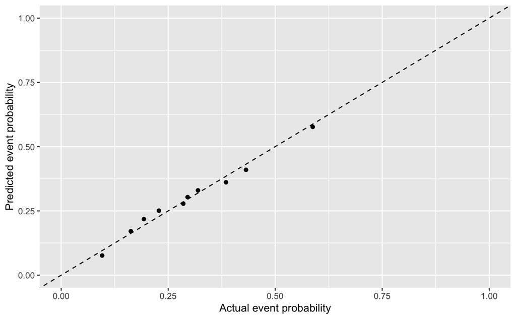

```r
# calibration plot: how well do estimated vs actual event probabilities relate to each other?
# -------------------------------------------------
actual_vs_predicted_glm<- data.frame(
  actual = ifelse(data_holdout[["away_win_flag"]] == "yes", 1, 0),
  predicted = predicted_glm_holdout
)

# order observations accordingly

num_groups <- 10

calibration_logit <- actual_vs_predicted_glm %>%
  # ntile: assign group ids based on a variable. similar to "cut".
  mutate(predicted_score_group = ntile(predicted, num_groups)) %>%
  group_by(predicted_score_group) %>%
  summarise(mean_actual = mean(actual), mean_predicted = mean(predicted), num_obs = n())

ggplot(calibration_logit,aes(x = mean_actual, y = mean_predicted)) +
  geom_point() +
  geom_abline(intercept = 0, slope = 1, linetype = "dashed") +
  labs(x = "Actual event probability", y = "Predicted event probability") +
  ylim(0, 1) + xlim(0, 1)
```

```r
# the Brier score: MSE applied to classification evaluation

brier <- RMSE(actual_vs_predicted_glm[["predicted"]], actual_vs_predicted_glm[["actual"]])^2
message(paste0("Brier score: ", round(brier, digits = 4)))
```

```
Brier score: 0.1898
```

A szimpla logisztikus regresszió jól kalibrált.

2. CALIBRATION TEST - Bayes Logistic Regression

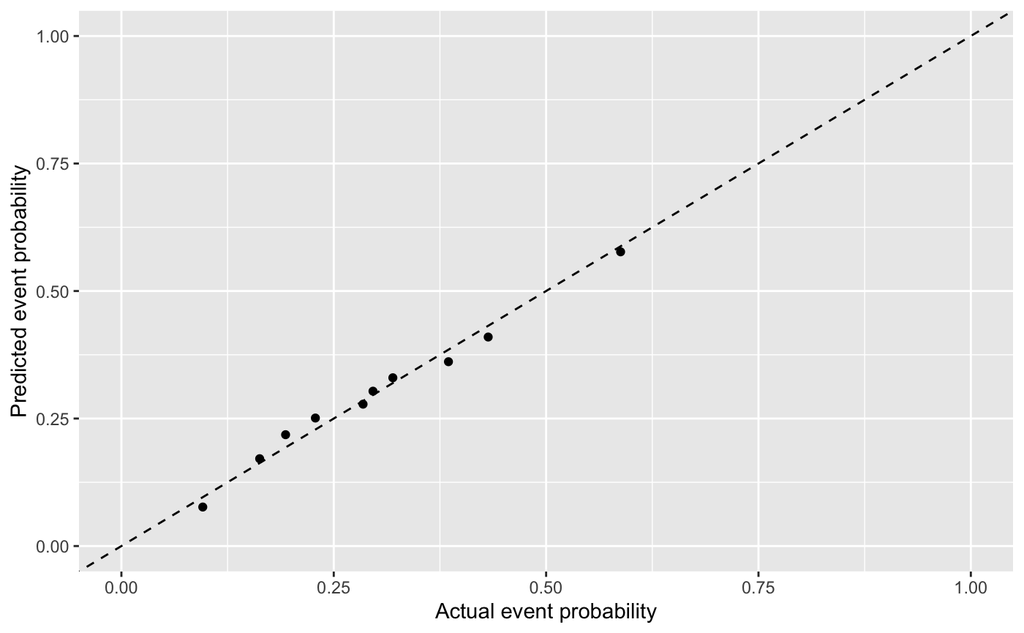

```r
# calibration plot: how well do estimated vs actual event probabilities relate to each other?
# -------------------------------------------------
actual_vs_predicted_baysesglm<- data.frame(
  actual = ifelse(data_holdout[["away_win_flag"]] == "yes", 1, 0),
  predicted = predicted_bayesglm_holdout
)

# order observations accordingly

num_groups <- 10

calibration_logit <- actual_vs_predicted_baysesglm %>%
  # ntile: assign group ids based on a variable. similar to "cut".
  mutate(predicted_score_group = ntile(predicted, num_groups)) %>%
  group_by(predicted_score_group) %>%
  summarise(mean_actual = mean(actual), mean_predicted = mean(predicted), num_obs = n())

ggplot(calibration_logit,aes(x = mean_actual, y = mean_predicted)) +
  geom_point() +
  geom_abline(intercept = 0, slope = 1, linetype = "dashed") +
  labs(x = "Actual event probability", y = "Predicted event probability") +
  ylim(0, 1) + xlim(0, 1)
```

```r
# the Brier score: MSE applied to classification evaluation

brier <- RMSE(actual_vs_predicted_baysesglm[["predicted"]], actual_vs_predicted_baysesglm[["actual"]])^2
message(paste0("Brier score: ", round(brier, digits = 4)))
```

```
Brier score: 0.1898
```

A Bayes Logreg modell jól kalibrált.

3. CALIBRATION TEST - GLM NET

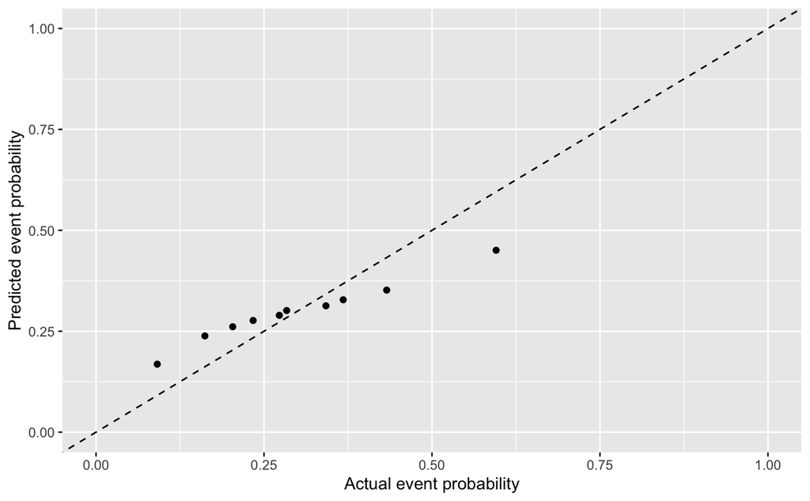

```r
# calibration plot: how well do estimated vs actual event probabilities relate to each other?
# -------------------------------------------------
actual_vs_predicted_glmnet<- data.frame(
  actual = ifelse(data_holdout[["away_win_flag"]] == "yes", 1, 0),
  predicted = predicted_glmnet_holdout
)

# order observations accordingly

num_groups <- 10

calibration_logit <- actual_vs_predicted_glmnet %>%
  # ntile: assign group ids based on a variable. similar to "cut".
  mutate(predicted_score_group = ntile(predicted, num_groups)) %>%
  group_by(predicted_score_group) %>%
  summarise(mean_actual = mean(actual), mean_predicted = mean(predicted), num_obs = n())

ggplot(calibration_logit,aes(x = mean_actual, y = mean_predicted)) +
  geom_point() +
  geom_abline(intercept = 0, slope = 1, linetype = "dashed") +
  labs(x = "Actual event probability", y = "Predicted event probability") +
  ylim(0, 1) + xlim(0, 1)
```

```r
# the Brier score: MSE applied to classification evaluation

brier <- RMSE(actual_vs_predicted_glmnet[["predicted"]], actual_vs_predicted_glmnet[["actual"]])^2
message(paste0("Brier score: ", round(brier, digits = 4)))
```

```
Brier score: 0.1944
```

Nem jól kalibrált modell a GLM Net.

4. CALIBRATION TEST - XGB

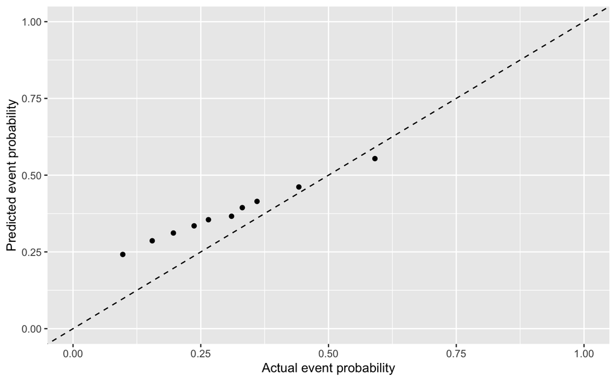

```r
# calibration plot: how well do estimated vs actual event probabilities relate to each other?
# -------------------------------------------------
actual_vs_predicted_xgb<- data.frame(
  actual = ifelse(data_holdout[["away_win_flag"]] == "yes", 1, 0),
  predicted = predicted_xgb_holdout
)

# order observations accordingly

num_groups <- 10

calibration_logit <- actual_vs_predicted_xgb %>%
  # ntile: assign group ids based on a variable. similar to "cut".
  mutate(predicted_score_group = ntile(predicted, num_groups)) %>%
  group_by(predicted_score_group) %>%
  summarise(mean_actual = mean(actual), mean_predicted = mean(predicted), num_obs = n())

ggplot(calibration_logit,aes(x = mean_actual, y = mean_predicted)) +
  geom_point() +
  geom_abline(intercept = 0, slope = 1, linetype = "dashed") +
  labs(x = "Actual event probability", y = "Predicted event probability") +
  ylim(0, 1) + xlim(0, 1)
```

```r
# the Brier score: MSE applied to classification evaluation

brier <- RMSE(actual_vs_predicted_xgb[["predicted"]], actual_vs_predicted_xgb[["actual"]])^2
message(paste0("Brier score: ", round(brier, digits = 4)))
```

```
Brier score: 0.1978
```

Nem jól kalibrált a modell a XGB modell, hiába tűnik magasnak a pontossága. Döntés: nem használom.

5. CALIBRATION TEST - GBM

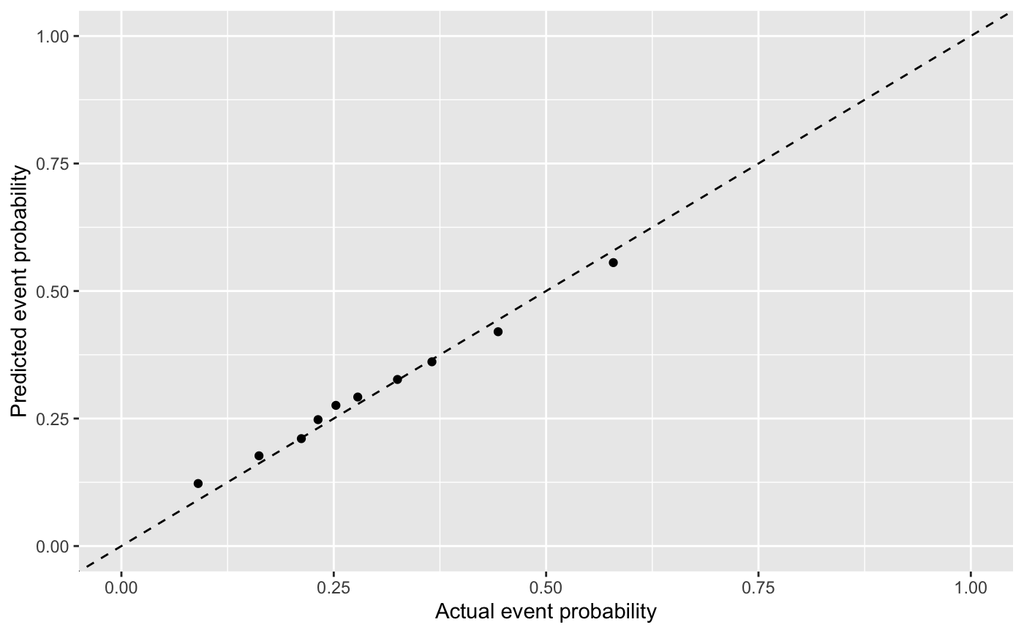

```r
# calibration plot: how well do estimated vs actual event probabilities relate to each other?
# -------------------------------------------------
actual_vs_predicted_gmb<- data.frame(
  actual = ifelse(data_holdout[["away_win_flag"]] == "yes", 1, 0),
  predicted = predicted_gbm_holdout
)

# order observations accordingly

num_groups <- 10

calibration_logit <- actual_vs_predicted_gmb %>%
  # ntile: assign group ids based on a variable. similar to "cut".
  mutate(predicted_score_group = ntile(predicted, num_groups)) %>%
  group_by(predicted_score_group) %>%
  summarise(mean_actual = mean(actual), mean_predicted = mean(predicted), num_obs = n())

ggplot(calibration_logit,aes(x = mean_actual, y = mean_predicted)) +
  geom_point() +
  geom_abline(intercept = 0, slope = 1, linetype = "dashed") +
  labs(x = "Actual event probability", y = "Predicted event probability") +
  ylim(0, 1) + xlim(0, 1)
```

```r
# the Brier score: MSE applied to classification evaluation

brier <- RMSE(actual_vs_predicted_gmb[["predicted"]], actual_vs_predicted_gmb[["actual"]])^2
message(paste0("Brier score: ", round(brier, digits = 4)))
```

```
Brier score: 0.1889
```

Egész jól kalibrált modell a GBM.

6. CALIBRATION TEST - Random Forest

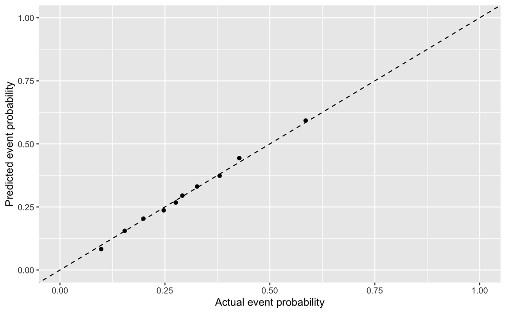

```r
# calibration plot: how well do estimated vs actual event probabilities relate to each other?
# -------------------------------------------------
actual_vs_predicted_rf <- data.frame(
  actual = ifelse(data_holdout[["away_win_flag"]] == "yes", 1, 0),
  predicted = predicted_rf_holdout
)

# order observations accordingly

num_groups <- 10

calibration_logit <- actual_vs_predicted_rf %>%
  # ntile: assign group ids based on a variable. similar to "cut".
  mutate(predicted_score_group = ntile(predicted, num_groups)) %>%
  group_by(predicted_score_group) %>%
  summarise(mean_actual = mean(actual), mean_predicted = mean(predicted), num_obs = n())

ggplot(calibration_logit,aes(x = mean_actual, y = mean_predicted)) +
  geom_point() +
  geom_abline(intercept = 0, slope = 1, linetype = "dashed") +
  labs(x = "Actual event probability", y = "Predicted event probability") +
  ylim(0, 1) + xlim(0, 1)
```

```r
# the Brier score: MSE applied to classification evaluation

brier <- RMSE(actual_vs_predicted_rf[["predicted"]], actual_vs_predicted_rf[["actual"]])^2
message(paste0("Brier score: ", round(brier, digits = 4)))
```

```
Brier score: 0.1902
```

Nagyon jól kalibrált modell a Random Forest.

7. CALIBRATION TEST - SVM

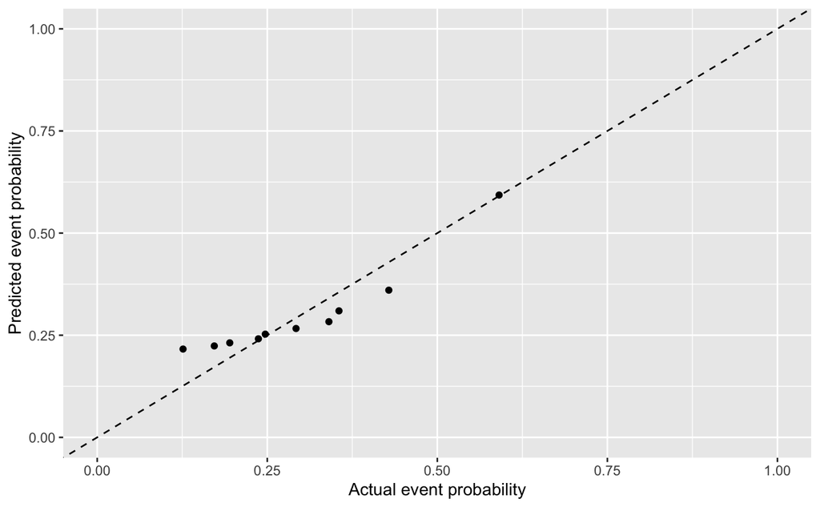

```r
# calibration plot: how well do estimated vs actual event probabilities relate to each other?
# -------------------------------------------------
actual_vs_predicted_svm <- data.frame(
  actual = ifelse(data_holdout[["away_win_flag"]] == "yes", 1, 0),
  predicted = predicted_svm_holdout
)

# order observations accordingly

num_groups <- 10

calibration_logit <- actual_vs_predicted_svm %>%
  # ntile: assign group ids based on a variable. similar to "cut".
  mutate(predicted_score_group = ntile(predicted, num_groups)) %>%
  group_by(predicted_score_group) %>%
  summarise(mean_actual = mean(actual), mean_predicted = mean(predicted), num_obs = n())

ggplot(calibration_logit,aes(x = mean_actual, y = mean_predicted)) +
  geom_point() +
  geom_abline(intercept = 0, slope = 1, linetype = "dashed") +
  labs(x = "Actual event probability", y = "Predicted event probability") +
  ylim(0, 1) + xlim(0, 1)
```

```r
# the Brier score: MSE applied to classification evaluation

brier <- RMSE(actual_vs_predicted_svm[["predicted"]], actual_vs_predicted_svm[["actual"]])^2
message(paste0("Brier score: ", round(brier, digits = 4)))
```

```
Brier score: 0.1941
```

Nagyon rosszul kalibrált az SVM modell. Döntés: nem használom.

8. CALIBRATION TEST - Naive Bayes

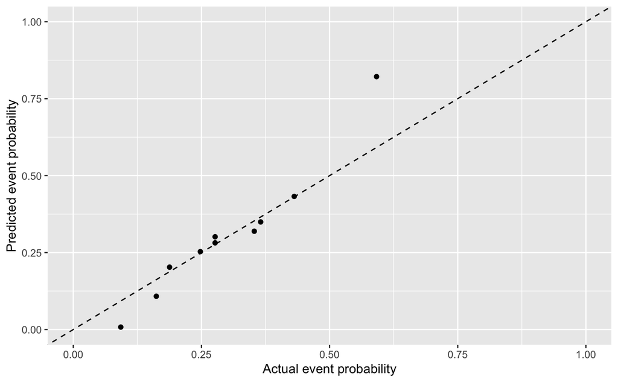

```r
# calibration plot: how well do estimated vs actual event probabilities relate to each other?
# -------------------------------------------------
actual_vs_predicted_nb <- data.frame(
  actual = ifelse(data_holdout[["away_win_flag"]] == "yes", 1, 0),
  predicted = predicted_nb_holdout
)

# order observations accordingly

num_groups <- 10

calibration_logit <- actual_vs_predicted_nb %>%
  # ntile: assign group ids based on a variable. similar to "cut".
  mutate(predicted_score_group = ntile(predicted, num_groups)) %>%
  group_by(predicted_score_group) %>%
  summarise(mean_actual = mean(actual), mean_predicted = mean(predicted), num_obs = n())

ggplot(calibration_logit,aes(x = mean_actual, y = mean_predicted)) +
  geom_point() +
  geom_abline(intercept = 0, slope = 1, linetype = "dashed") +
  labs(x = "Actual event probability", y = "Predicted event probability") +
  ylim(0, 1) + xlim(0, 1)
```

```r
# the Brier score: MSE applied to classification evaluation

brier <- RMSE(actual_vs_predicted_nb[["predicted"]], actual_vs_predicted_nb[["actual"]])^2
message(paste0("Brier score: ", round(brier, digits = 4)))
```

```
Brier score: 0.1971
```

Nagyon rosszul kalibrált a Naive Bayes modell. Döntés: nem használom.

9. CALIBRATION TEST - KNN

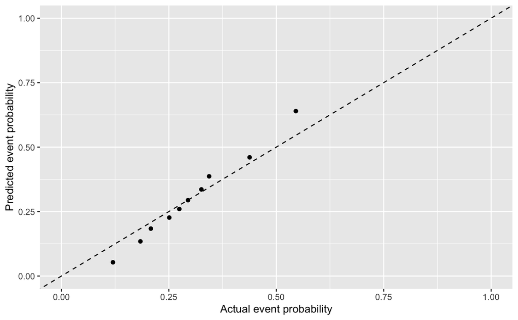

```r
# calibration plot: how well do estimated vs actual event probabilities relate to each other?
# -------------------------------------------------
actual_vs_predicted_knn <- data.frame(
  actual = ifelse(data_holdout[["away_win_flag"]] == "yes", 1, 0),
  predicted = predicted_knn_holdout
)

# order observations accordingly

num_groups <- 10

calibration_logit <- actual_vs_predicted_knn %>%
  # ntile: assign group ids based on a variable. similar to "cut".
  mutate(predicted_score_group = ntile(predicted, num_groups)) %>%
  group_by(predicted_score_group) %>%
  summarise(mean_actual = mean(actual), mean_predicted = mean(predicted), num_obs = n())

ggplot(calibration_logit,aes(x = mean_actual, y = mean_predicted)) +
  geom_point() +
  geom_abline(intercept = 0, slope = 1, linetype = "dashed") +
  labs(x = "Actual event probability", y = "Predicted event probability") +
  ylim(0, 1) + xlim(0, 1)
```

```r
# the Brier score: MSE applied to classification evaluation

brier <- RMSE(actual_vs_predicted_knn[["predicted"]], actual_vs_predicted_knn[["actual"]])^2
message(paste0("Brier score: ", round(brier, digits = 4)))
```

```
Brier score: 0.1966
```

Nagyon rosszul kalibrált a KNN modell. Döntés: nem használom.